# MGT 599 Capstone - Group 4

## Week 2 Submission

April 2026

This notebook runs the full week 2 pipeline from start to finish. We load the raw data, clean it, explore it, build features, and save the final files for modeling next week. Run the cells top to bottom.

## Setup

```python
import sys
import warnings
from pathlib import Path

import pandas as pd
import matplotlib.pyplot as plt
import seaborn as sns
from sklearn.feature_extraction.text import TfidfVectorizer

warnings.filterwarnings('ignore')

PROJECT_ROOT = Path.cwd().parent if Path.cwd().name == 'notebooks' else Path.cwd()
sys.path.insert(0, str(PROJECT_ROOT / 'scripts'))
sys.path.insert(0, str(PROJECT_ROOT))

from common_utils import (
    BASE_PATH, DATA_PATH, CLEANED_PATH,
    TASK1_FEATURE_PATH, TASK2_FEATURE_PATH, MODEL_READY_PATH, FINDINGS_PATH,
    ensure_folders, load_task_dataframe, guess_target_column, guess_text_columns,
    add_basic_text_features, add_keyword_features, safe_text, combine_text_fields,
    simple_missing_summary, find_weak_features, analyze_imbalance, set_chart_style,
    save_dataframe
)

DB_PATH = PROJECT_ROOT / 'data' / 'db' / 'analytics.duckdb'

set_chart_style()
ensure_folders()

print('project root:', PROJECT_ROOT)
print('db path:', DB_PATH)
print('ready')
```

```
project root: C:\Users\akash\Desktop\capstone MGT 599
db path: C:\Users\akash\Desktop\capstone MGT 599\data\db\analytics.duckdb
ready
```

## Step 1 - load raw data into DuckDB

```python
from data.loader import DataLoader
from data.validator import DataValidator

loader = DataLoader(str(PROJECT_ROOT))
loader.connect()
loader.load_data()
loader.validate_tables()

validator = DataValidator(loader.con)
validator.validate_task1()
validator.validate_task2()

loader.con.close()
print('step 1 done')
```

```
Connected to DuckDB
Loading Task 1...
```

```
Loading Task 2...
```

```
Data loaded successfully
Task1 rows: 53585
Task2 rows: 27537

--- VALIDATING TASK1 ---
Rows: 53585
Nulls: {'CompanyId': 0, 'AsOfDate': 0, 'LongProfile': 0, 'SegmentName': 0, 'SegmentDescription': 27524, 'MstarGlobal': 0}
Duplicate CompanyId + AsOfDate + SegmentName: 1233

--- VALIDATING TASK2 ---
Rows: 27537
```

```
Nulls: {'CompanyId': 0, 'AsOfDate': 0, 'SegmentName': 0, 'SegmentDescription': 0, 'Subindustry': 0}
```

```
Duplicate CompanyId + AsOfDate + SegmentName: 374
step 1 done
```

## Step 2 - clean the data and export to CSVs

```python
from data.cleaner import DataCleaner

cleaner = DataCleaner(str(DB_PATH))
cleaner.connect()
cleaner.clean_task1()
cleaner.clean_task2()
cleaner.export_to_cleaned(str(CLEANED_PATH))
cleaner.con.close()

print('files in data/cleaned/:')
for f in sorted(CLEANED_PATH.glob('*.csv')):
    print(f'  {f.name}  ({f.stat().st_size / 1e6:.1f} MB)')

print('step 2 done')
```

```
Connected to DuckDB

Cleaning task1 → task1_clean
```

```
Cleaning task2 → task2_clean
```

```
Exporting task1_clean -> C:/Users/akash/Desktop/capstone MGT 599/data/cleaned/task1_clean.csv
Exporting task2_clean -> C:/Users/akash/Desktop/capstone MGT 599/data/cleaned/task2_clean.csv
```

```
Export to data/cleaned/ done.
files in data/cleaned/:
  task1_clean.csv  (38.6 MB)
  task2_clean.csv  (7.3 MB)
step 2 done
```

## Step 3 - load cleaned data and look at it

```python
task1 = load_task_dataframe('task1')
task2 = load_task_dataframe('task2')

print('task1 shape:', task1.shape)
print('task1 columns:', list(task1.columns))
print()
print('task2 shape:', task2.shape)
print('task2 columns:', list(task2.columns))
```

```
Loading task1 from: C:\Users\akash\Desktop\capstone MGT 599\data\cleaned\task1_clean.csv
```

```
Loaded! Shape: (53585, 10)
Loading task2 from: C:\Users\akash\Desktop\capstone MGT 599\data\cleaned\task2_clean.csv
Loaded! Shape: (27537, 5)
task1 shape: (53585, 10)
task1 columns: ['CompanyId', 'AsOfDate', 'LongProfile', 'SegmentName', 'SegmentDescription', 'Revenue', 'total_revenue_company_as_of', 'revenue_share', 'is_largest_share_segment', 'MstarGlobal']

task2 shape: (27537, 5)
task2 columns: ['CompanyId', 'AsOfDate', 'SegmentName', 'SegmentDescription', 'Subindustry']
```

```python
task1.head(3)
```

|  | CompanyId | AsOfDate | LongProfile | SegmentName | SegmentDescription | Revenue | total_revenue_company_as_of | revenue_share | is_largest_share_segment | MstarGlobal |
| --- | --- | --- | --- | --- | --- | --- | --- | --- | --- | --- |
| 0 | AX2S5G3YJ2 | 2024-12-31 | The company is an American packaged-food manuf... | Frozen & Vegetables | Frozen & Vegetables segment includes the Green... | 395785000.0 | 1.932454e+09 | 0.204810 | False | 20525040 |
| 1 | AX2S5G3YJ2 | 2024-12-31 | The company is an American packaged-food manuf... | Meals | Meals segment includes, among others, the Orte... | 462397000.0 | 1.932454e+09 | 0.239280 | False | 20525040 |
| 2 | AX2S5G3YJ2 | 2024-12-31 | The company is an American packaged-food manuf... | Specialty | Specialty segment includes, among others, the ... | 679076000.0 | 1.932454e+09 | 0.351406 | True | 20525040 |

```python
task2.head(3)
```

|  | CompanyId | AsOfDate | SegmentName | SegmentDescription | Subindustry |
| --- | --- | --- | --- | --- | --- |
| 0 | 3IZBDS5MVU | 2020-12-31 | Substrates | Substrates engages in the design, development,... | 3113001001 |
| 1 | 3IZBDS5MVU | 2020-12-31 | Raw Materials and Other | Raw Materials and Other pertains to the sale o... | 3113001001 |
| 2 | AX2S5G3YJ2 | 2024-12-31 | Frozen & Vegetables | Frozen & Vegetables segment includes the Green... | 2052504001 |

### missing values

```python
print('task 1 missing:')
display(simple_missing_summary(task1))

print('task 2 missing:')
display(simple_missing_summary(task2))
```

```
task 1 missing:
```

|  | column | missing_count | missing_percent |
| --- | --- | --- | --- |
| 4 | SegmentDescription | 27524 | 51.37 |
| 0 | CompanyId | 0 | 0.00 |
| 1 | AsOfDate | 0 | 0.00 |
| 2 | LongProfile | 0 | 0.00 |
| 3 | SegmentName | 0 | 0.00 |
| 5 | Revenue | 0 | 0.00 |
| 6 | total_revenue_company_as_of | 0 | 0.00 |
| 7 | revenue_share | 0 | 0.00 |
| 8 | is_largest_share_segment | 0 | 0.00 |
| 9 | MstarGlobal | 0 | 0.00 |

```
task 2 missing:
```

|  | column | missing_count | missing_percent |
| --- | --- | --- | --- |
| 0 | CompanyId | 0 | 0.0 |
| 1 | AsOfDate | 0 | 0.0 |
| 2 | SegmentName | 0 | 0.0 |
| 3 | SegmentDescription | 0 | 0.0 |
| 4 | Subindustry | 0 | 0.0 |

### class distribution - industry (task 1)

```
Guessed target column for task1: MstarGlobal
```

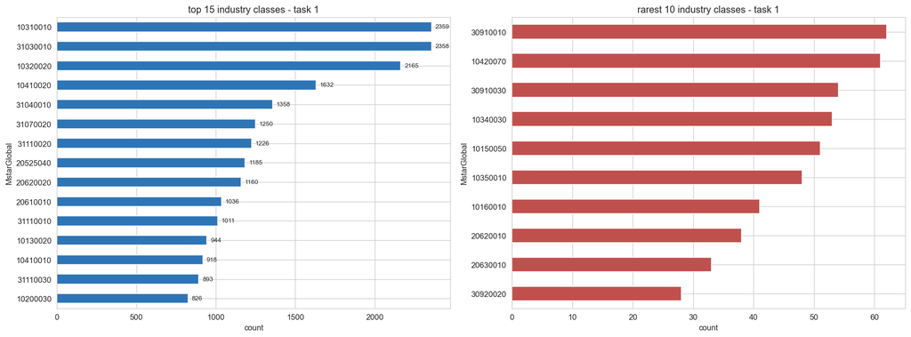

```
task 1 industry label breakdown:
  unique classes: 145
  top 3 cover: 12.8%
  classes with < 10 rows: 0
```

```python
t1_target = guess_target_column(task1, 'task1')
t1_counts = task1[t1_target].value_counts()

fig, axes = plt.subplots(1, 2, figsize=(16, 6))

t1_counts.head(15).sort_values().plot(kind='barh', ax=axes[0], color='#2E75B6')
axes[0].set_title('top 15 industry classes - task 1')
axes[0].set_xlabel('count')
for i, v in enumerate(t1_counts.head(15).sort_values().values):
    axes[0].text(v + t1_counts.max() * 0.01, i, str(v), va='center', fontsize=8)

t1_counts.tail(10).sort_values().plot(kind='barh', ax=axes[1], color='#C0504D')
axes[1].set_title('rarest 10 industry classes - task 1')
axes[1].set_xlabel('count')

plt.tight_layout()
plt.show()

t1_imb = analyze_imbalance(task1[t1_target], 'task 1 industry')
```

### class distribution - subindustry (task 2)

```
Guessed target column for task2: Subindustry
```

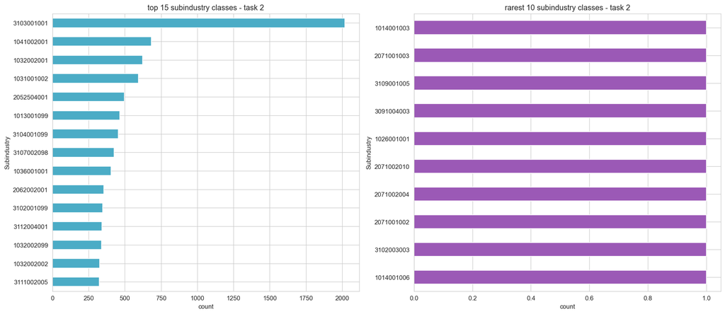

```
task 2 subindustry label breakdown:
  unique classes: 428
  top 3 cover: 12.1%
  classes with < 10 rows: 99
```

```python
t2_target = guess_target_column(task2, 'task2')
t2_counts = task2[t2_target].value_counts()

fig, axes = plt.subplots(1, 2, figsize=(16, 7))

t2_counts.head(15).sort_values().plot(kind='barh', ax=axes[0], color='#4BACC6')
axes[0].set_title('top 15 subindustry classes - task 2')
axes[0].set_xlabel('count')

t2_counts.tail(10).sort_values().plot(kind='barh', ax=axes[1], color='#9B59B6')
axes[1].set_title('rarest 10 subindustry classes - task 2')
axes[1].set_xlabel('count')

plt.tight_layout()
plt.show()

t2_imb = analyze_imbalance(task2[t2_target], 'task 2 subindustry')
```

### text length distributions

```
task 1 text columns: ['LongProfile', 'SegmentDescription', 'SegmentName']
task 2 text columns: ['SegmentDescription', 'SegmentName']
```

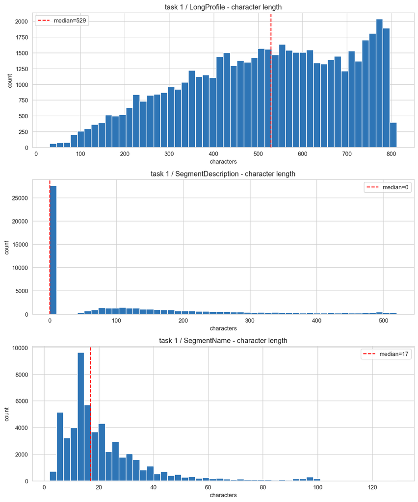

```python
t1_text_cols = guess_text_columns(task1)
t2_text_cols = guess_text_columns(task2)

print('task 1 text columns:', t1_text_cols)
print('task 2 text columns:', t2_text_cols)

fig, axes = plt.subplots(len(t1_text_cols), 1,
                         figsize=(10, 4 * max(len(t1_text_cols), 1)),
                         squeeze=False)

for i, col in enumerate(t1_text_cols):
    lengths = safe_text(task1[col]).apply(len)
    axes[i][0].hist(lengths, bins=50, color='#2E75B6', edgecolor='white')
    axes[i][0].set_title(f'task 1 / {col} - character length')
    axes[i][0].set_xlabel('characters')
    axes[i][0].set_ylabel('count')
    med = lengths.median()
    axes[i][0].axvline(med, color='red', linestyle='--', label=f'median={med:.0f}')
    axes[i][0].legend()

plt.tight_layout()
plt.show()
```

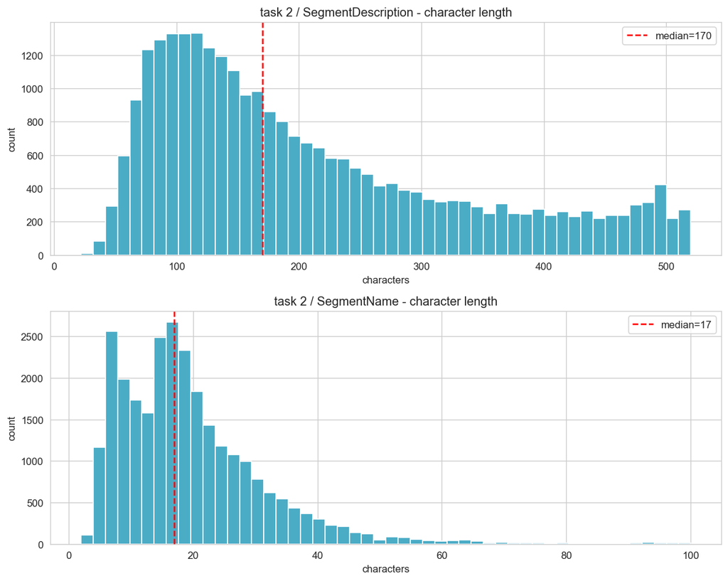

```python
fig, axes = plt.subplots(len(t2_text_cols), 1,
                         figsize=(10, 4 * max(len(t2_text_cols), 1)),
                         squeeze=False)

for i, col in enumerate(t2_text_cols):
    lengths = safe_text(task2[col]).apply(len)
    axes[i][0].hist(lengths, bins=50, color='#4BACC6', edgecolor='white')
    axes[i][0].set_title(f'task 2 / {col} - character length')
    axes[i][0].set_xlabel('characters')
    axes[i][0].set_ylabel('count')
    med = lengths.median()
    axes[i][0].axvline(med, color='red', linestyle='--', label=f'median={med:.0f}')
    axes[i][0].legend()

plt.tight_layout()
plt.show()
```

## Step 4 - task 1 feature engineering

We build three types of features: text stats (length, word count etc), keyword flags (0 or 1 per keyword), and TF-IDF (300 numbers per company based on what words appear in the description).

```python
task1_fe = task1.copy()
task1_fe = add_basic_text_features(task1_fe, t1_text_cols)

t1_main_col_pref = ['LongProfile', 'CompanyDescription', 'SegmentDescription']
t1_main_col = next((c for c in t1_main_col_pref if c in task1_fe.columns),
                   t1_text_cols[0] if t1_text_cols else None)
print('main text column for tfidf:', t1_main_col)

task1_fe['short_desc_flag'] = (
    safe_text(task1_fe[t1_main_col]).str.split().str.len() < 5
).astype(int)
print('short descriptions (<5 words):', task1_fe['short_desc_flag'].sum())

industry_keywords = [
    'bank', 'finance', 'financial', 'insurance', 'retail',
    'software', 'technology', 'healthcare', 'medical', 'pharma',
    'energy', 'oil', 'gas', 'manufacturing', 'industrial',
    'telecom', 'transport', 'logistics',
]
task1_fe = add_keyword_features(task1_fe, t1_main_col, industry_keywords, prefix='industry_kw')
print('keyword features added:', len(industry_keywords))
```

```
main text column for tfidf: LongProfile
```

```
short descriptions (<5 words): 0
```

```
keyword features added: 18
```

```python
print('building tfidf...')
tfidf_vec1 = TfidfVectorizer(max_features=300, stop_words='english', ngram_range=(1, 2))
X1 = tfidf_vec1.fit_transform(safe_text(task1_fe[t1_main_col]))
tfidf1_df = pd.DataFrame(X1.toarray(),
                          columns=[f'tfidf_{n}' for n in tfidf_vec1.get_feature_names_out()])
print('tfidf shape:', tfidf1_df.shape)

task1_fe = combine_text_fields(task1_fe, t1_text_cols, 'combined_text')
comb_vec1 = TfidfVectorizer(max_features=300, stop_words='english', ngram_range=(1, 2))
Xc1 = comb_vec1.fit_transform(safe_text(task1_fe['combined_text']))
comb1_df = pd.DataFrame(Xc1.toarray(),
                         columns=[f'comb_tfidf_{n}' for n in comb_vec1.get_feature_names_out()])
print('combined tfidf shape:', comb1_df.shape)

task1_full = pd.concat([task1_fe.reset_index(drop=True), tfidf1_df.reset_index(drop=True)], axis=1)
print('full task 1 feature file shape:', task1_full.shape)

save_dataframe(task1_fe,   TASK1_FEATURE_PATH / 'task1_features_basic_v1.csv')
save_dataframe(tfidf1_df,  TASK1_FEATURE_PATH / 'task1_tfidf_features_v1.csv')
save_dataframe(comb1_df,   TASK1_FEATURE_PATH / 'task1_combined_tfidf_v1.csv')
save_dataframe(task1_full, TASK1_FEATURE_PATH / 'task1_features_full_v1.csv')
print('task 1 files saved')
```

```
building tfidf...
```

```
tfidf shape: (53585, 300)
```

```
combined tfidf shape: (53585, 300)
full task 1 feature file shape: (53585, 345)
```

```
Saved: C:\Users\akash\Desktop\capstone MGT 599\outputs\features\task1\task1_features_basic_v1.csv
```

```
Saved: C:\Users\akash\Desktop\capstone MGT 599\outputs\features\task1\task1_tfidf_features_v1.csv
```

```
Saved: C:\Users\akash\Desktop\capstone MGT 599\outputs\features\task1\task1_combined_tfidf_v1.csv
```

```
Saved: C:\Users\akash\Desktop\capstone MGT 599\outputs\features\task1\task1_features_full_v1.csv
task 1 files saved
```

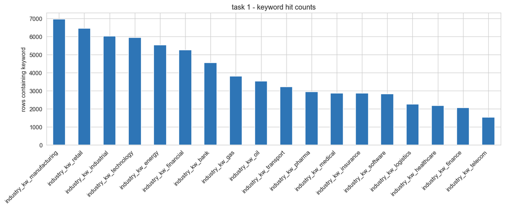

```python
kw_cols1 = [c for c in task1_fe.columns if c.startswith('industry_kw_')]
kw_hits1 = task1_fe[kw_cols1].sum().sort_values(ascending=False)

plt.figure(figsize=(12, 5))
kw_hits1.plot(kind='bar', color='#2E75B6', edgecolor='white')
plt.title('task 1 - keyword hit counts')
plt.ylabel('rows containing keyword')
plt.xticks(rotation=45, ha='right')
plt.tight_layout()
plt.show()
```

## Step 5 - task 2 feature engineering

```python
task2_fe = task2.copy()
task2_fe = add_basic_text_features(task2_fe, t2_text_cols)

t2_main_col_pref = ['SegmentDescription', 'Segment Description', 'SegmentName', 'LongProfile']
t2_main_col = next((c for c in t2_main_col_pref if c in task2_fe.columns),
                   t2_text_cols[0] if t2_text_cols else None)
print('main text column for tfidf:', t2_main_col)

task2_fe['short_desc_flag'] = (
    safe_text(task2_fe[t2_main_col]).str.split().str.len() < 5
).astype(int)
print('short descriptions (<5 words):', task2_fe['short_desc_flag'].sum())

activity_keywords = [
    'delivery', 'transport', 'logistics', 'cloud', 'platform',
    'payments', 'medical', 'device', 'manufacturing', 'processing',
    'software', 'retail', 'distribution', 'construction', 'consulting',
    'analytics', 'security', 'energy', 'packaging', 'warehousing',
    'saas', 'subscription', 'staffing', 'outsourcing', 'brokerage', 'leasing',
]
task2_fe = add_keyword_features(task2_fe, t2_main_col, activity_keywords, prefix='activity_kw')
print('keyword features added:', len(activity_keywords))
```

```
main text column for tfidf: SegmentDescription
short descriptions (<5 words): 23
```

```
keyword features added: 26
```

```python
print('building tfidf...')
tfidf_vec2 = TfidfVectorizer(max_features=300, stop_words='english', ngram_range=(1, 2))
X2 = tfidf_vec2.fit_transform(safe_text(task2_fe[t2_main_col]))
tfidf2_df = pd.DataFrame(X2.toarray(),
                          columns=[f'tfidf_{n}' for n in tfidf_vec2.get_feature_names_out()])
print('tfidf shape:', tfidf2_df.shape)

task2_fe = combine_text_fields(task2_fe, t2_text_cols, 'combined_text')
comb_vec2 = TfidfVectorizer(max_features=300, stop_words='english', ngram_range=(1, 2))
Xc2 = comb_vec2.fit_transform(safe_text(task2_fe['combined_text']))
comb2_df = pd.DataFrame(Xc2.toarray(),
                         columns=[f'comb_tfidf_{n}' for n in comb_vec2.get_feature_names_out()])
print('combined tfidf shape:', comb2_df.shape)

task2_full = pd.concat([task2_fe.reset_index(drop=True), tfidf2_df.reset_index(drop=True)], axis=1)
print('full task 2 shape:', task2_full.shape)

save_dataframe(task2_fe,   TASK2_FEATURE_PATH / 'task2_features_basic_v1.csv')
save_dataframe(tfidf2_df,  TASK2_FEATURE_PATH / 'task2_tfidf_features_v1.csv')
save_dataframe(comb2_df,   TASK2_FEATURE_PATH / 'task2_combined_tfidf_v1.csv')
save_dataframe(task2_full, TASK2_FEATURE_PATH / 'task2_features_full_v1.csv')
print('task 2 files saved')
```

```
building tfidf...
```

```
tfidf shape: (27537, 300)
```

```
combined tfidf shape: (27537, 300)
full task 2 shape: (27537, 343)
```

```
Saved: C:\Users\akash\Desktop\capstone MGT 599\outputs\features\task2\task2_features_basic_v1.csv
```

```
Saved: C:\Users\akash\Desktop\capstone MGT 599\outputs\features\task2\task2_tfidf_features_v1.csv
```

```
Saved: C:\Users\akash\Desktop\capstone MGT 599\outputs\features\task2\task2_combined_tfidf_v1.csv
```

```
Saved: C:\Users\akash\Desktop\capstone MGT 599\outputs\features\task2\task2_features_full_v1.csv
task 2 files saved
```

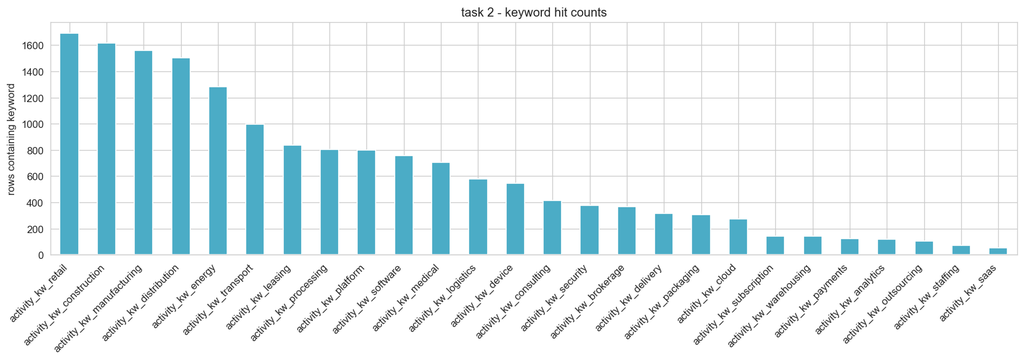

```python
kw_cols2 = [c for c in task2_fe.columns if c.startswith('activity_kw_')]
kw_hits2 = task2_fe[kw_cols2].sum().sort_values(ascending=False)

plt.figure(figsize=(14, 5))
kw_hits2.plot(kind='bar', color='#4BACC6', edgecolor='white')
plt.title('task 2 - keyword hit counts')
plt.ylabel('rows containing keyword')
plt.xticks(rotation=45, ha='right')
plt.tight_layout()
plt.show()
```

## Step 6 - model ready review

Check for columns where almost every row has the same value (not useful for a model), verify row counts, and save the final files.

```python
weak1 = [c for c, _ in find_weak_features(task1_full)]
weak2 = [c for c, _ in find_weak_features(task2_full)]

print('task 1 near-constant columns:', len(weak1))
print('task 2 near-constant columns:', len(weak2))

task1_ready = task1_full.drop(columns=weak1) if weak1 else task1_full.copy()
task2_ready = task2_full.drop(columns=weak2) if weak2 else task2_full.copy()

print('task 1 final shape:', task1_ready.shape)
print('task 2 final shape:', task2_ready.shape)
```

```
task 1 near-constant columns: 3
task 2 near-constant columns: 21
task 1 final shape: (53585, 342)
task 2 final shape: (27537, 322)
```

|  | feature group | count | dataset |
| --- | --- | --- | --- |
| 0 | text stats | 13 | task 1 |
| 1 | keyword flags | 18 | task 1 |
| 2 | tfidf | 300 | task 1 |
| 3 | other/original | 11 | task 1 |
| 4 | text stats | 8 | task 2 |
| 5 | keyword flags | 18 | task 2 |
| 6 | tfidf | 290 | task 2 |
| 7 | other/original | 6 | task 2 |

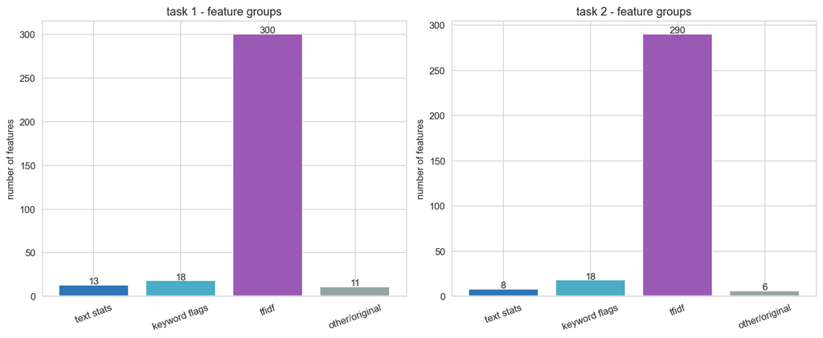

```python
def feature_group_summary(name, df):
    txt   = [c for c in df.columns if any(t in c for t in
             ['_char_len','_word_count','_unique_word','_avg_word','_has_text'])]
    kw    = [c for c in df.columns if '_kw_' in c]
    tf    = [c for c in df.columns if 'tfidf_' in c]
    other = len(df.columns) - len(txt) - len(kw) - len(tf)
    return pd.DataFrame({
        'feature group': ['text stats', 'keyword flags', 'tfidf', 'other/original'],
        'count': [len(txt), len(kw), len(tf), other]
    }).assign(dataset=name)

summary = pd.concat([
    feature_group_summary('task 1', task1_ready),
    feature_group_summary('task 2', task2_ready),
], ignore_index=True)

display(summary)

fig, axes = plt.subplots(1, 2, figsize=(12, 5))
colors = ['#2E75B6', '#4BACC6', '#9B59B6', '#95A5A6']

for i, (dname, grp) in enumerate(summary.groupby('dataset')):
    axes[i].bar(grp['feature group'], grp['count'], color=colors)
    axes[i].set_title(f'{dname} - feature groups')
    axes[i].set_ylabel('number of features')
    axes[i].tick_params(axis='x', rotation=20)
    for j, v in enumerate(grp['count']):
        axes[i].text(j, v + 1, str(v), ha='center', fontsize=10)

plt.tight_layout()
plt.show()
```

```python
save_dataframe(task1_ready, MODEL_READY_PATH / 'task1_model_ready_v1.csv')
save_dataframe(task2_ready, MODEL_READY_PATH / 'task2_model_ready_v1.csv')
print('model-ready files saved')
```

```
Saved: C:\Users\akash\Desktop\capstone MGT 599\outputs\model_ready\task1_model_ready_v1.csv
```

```
Saved: C:\Users\akash\Desktop\capstone MGT 599\outputs\model_ready\task2_model_ready_v1.csv
model-ready files saved
```

## Week 2 summary

```python
print('week 2 results')
print('-' * 40)
print(f'task 1 rows: {task1.shape[0]:,}  |  unique classes: {task1[t1_target].nunique()}')
print(f'task 2 rows: {task2.shape[0]:,}  |  unique classes: {task2[t2_target].nunique()}')
print()
print(f'task 1 top-3 classes cover: {t1_imb["top3_pct"]}% of data')
print(f'task 2 top-3 classes cover: {t2_imb["top3_pct"]}% of data')
print(f'task 1 rare classes (<10 rows): {t1_imb["rare_classes"]}')
print(f'task 2 rare classes (<10 rows): {t2_imb["rare_classes"]}')
print()
print(f'task 1 model-ready file: {task1_ready.shape}')
print(f'task 2 model-ready file: {task2_ready.shape}')
print()
for folder in [TASK1_FEATURE_PATH, TASK2_FEATURE_PATH, MODEL_READY_PATH]:
    csvs = list(folder.glob('*.csv'))
    print(f'{folder.relative_to(PROJECT_ROOT)}: {len(csvs)} csv file(s)')
```

```
week 2 results
----------------------------------------
task 1 rows: 53,585  |  unique classes: 145
task 2 rows: 27,537  |  unique classes: 428

task 1 top-3 classes cover: 12.8% of data
task 2 top-3 classes cover: 12.1% of data
task 1 rare classes (<10 rows): 0
task 2 rare classes (<10 rows): 99

task 1 model-ready file: (53585, 342)
task 2 model-ready file: (27537, 322)

outputs\features\task1: 4 csv file(s)
outputs\features\task2: 4 csv file(s)
outputs\model_ready: 2 csv file(s)
```

## What we found and what comes next

Some descriptions are empty or very short. We flagged those rows with short_desc_flag. The model won't get much signal from a blank description.

Next week we train baseline classifiers on the model-ready files (logistic regression and random forest), evaluate with F1-macro score, and see how well the predictions hold up.